# Análise Attack I e Attack II

Tiago Matos

2024-11-18

## Análise dos Dados

As análises realizadas a partir dos instrumentos Attack I e Attack II visaram compreender as relações entre barreiras de acesso aos serviços de saúde e o desfecho clínico do número de ataques no período de estudo. O software utilizado foi o R Studio versão 2024.04.2 de livre distribuição.

A primeira parte do trabalho consistiu em analisar o desfecho do número de ataques e sua relação com as barreiras de acesso que incluíram acesso a exames, medicamentos, atenção primária, internações e transporte. Os estudos Attack I e Attack II foram analisados separadamente. A análise inferencial foi feita, quando possível, para comparar a média entre os dois grupos analisados: com barreira *versus* sem barreira. O teste realizado foi o t de student e o nível de significância para o trabalho foi de p < 0,05.

Os dados omissos foram considerados como “não” para todas as perguntas “sim/não” sobre as barreiras de acesso. Caso algum destes campos fosse respondido como “sim” foi considerado com tendo barreira de acesso. Ao final de cada grupo de estudo Attack também foi inferido se havia alguma relação entre o número de ataques e os casos em que houve algum tipo de barreira de acesso. Em um segundo momento, foi feita uma junção dos dados dos estudos Attack I e Attack II e feitas novas estatísticas inferenciais, conforme mencionado acima.

### Attack I

#### Calculando a soma de ataques (Attack I)

Para calcular a relação entre a soma de ataques e as barreiras de acesso foi feita uma tratativa com os dados de ataque considerando os campos attack621 v2, “Número de ataques graves de asma no último ano” e attack211 v2, “Número de ataques graves de asma no último ano”. Os resultados foram então somados em uma única variável de soma.

#### Teste t entre as barreiras de exames e a soma de ataques (Attack I)

Para avaliar a relação entre as barreiras de exame e a soma de ataques foram considerados os campos attack533, “Se precisou de exames no serviço público, teve dificuldade na marcação dos exames?”, e attack599, “Você gastou recursos próprios com exames para asma, no último ano?”. Destaca-se que não houve significância estatística entre o número de ataques e as barreiras a exames.

Alguma barreira de exame?

| Barreira | N | Média | DP | t | GL | p | Inferior | Superior |
| --- | --- | --- | --- | --- | --- | --- | --- | --- |
| Não | 179 | 2.865922 | 4.349081 | -0.5981804 | 19.19011 | 5.57e-01 | -3.600662 | 1.999172 |
| Sim | 18 | 3.666667 | 5.509350 |  |  |  |  |  |

#### Teste t entre as barreiras de transporte e a soma de ataques (Attack I)

Para avaliar a relação entre as barreiras de transporte e a soma de ataques foi considerado o campo attack546, “Você já deixou de procurar atendimento médico por falta de dinheiro para o transporte?”. Destaca-se que não houve significância estatística entre o número de ataques e as barreiras a transporte.

Alguma barreira de transporte?

| Barreira | N | Média | DP | t | GL | p | Inferior | Superior |
| --- | --- | --- | --- | --- | --- | --- | --- | --- |
| Não | 97 | 3.164948 | 4.938540 | 0.6972705 | 183.5006 | 4.87e-01 | -0.8140647 | 1.703962 |
| Sim | 100 | 2.720000 | 3.946818 |  |  |  |  |  |

#### Teste t entre as barreiras de atenção básica e a soma de ataques (Attack I)

Para a análise das barreiras sobre a atenção básica foram extraídos dados dos campos attack527, “Você teve dificuldade de acesso à rede de atenção básica do SUS, nesta ocasião?” , attack594,“Qual a sua principal forma de utilização de serviços de saúde?”, e attack596, “Você utiliza consultas particulares para o tratamento da asma?”. Não houve significância estatística.

Alguma barreira de atenção?

| Barreira | N | Média | DP | t | GL | p | Inferior | Superior |
| --- | --- | --- | --- | --- | --- | --- | --- | --- |
| Não | 181 | 2.839779 | 4.438689 | -1.010977 | 17.49945 | 3.26e-01 | -3.76889 | 1.323448 |
| Sim | 16 | 4.062500 | 4.654299 |  |  |  |  |  |

#### Teste t entre as barreiras de medicamentos e a soma de ataques (Attack I

Alguma barreira de medicamento?

| Barreira | N | Média | DP | t | GL | p | Inferior | Superior |
| --- | --- | --- | --- | --- | --- | --- | --- | --- |
| Não | 41 | 1.878049 | 2.666413 | -2.367711 | 115.122 | 1.96e-02 | -2.460837 | -0.2189634 |
| Sim | 156 | 3.217949 | 4.786129 |  |  |  |  |  |

#### Teste t entre as barreiras de internação e a soma de ataques (Attack I)

Para avaliar a relação entre as barreiras de transporte e a soma de ataques foi considerado o campo attack929, “Você gastou recursos com internação em consequência da asma no último ano?”. Não houve significância estatística na diferença entre as médias nesse caso.

Alguma barreira de internação?

| Barreira | N | Média | DP | t | GL | p | Inferior | Superior |
| --- | --- | --- | --- | --- | --- | --- | --- | --- |
| Não | 195 | 2.882051 | 4.429451 | -1.598577 | 1.016494 | 3.53e-01 | -48.59555 | 37.35965 |
| Sim | 2 | 8.500000 | 4.949747 |  |  |  |  |  |

#### Barreiras únicas (Attack I)

Como mencionando, foi feita análise entre os casos em que houve pelo menos uma barreira de acesso e o número de ataques. Observa-se que houve significância estatística entre ter pelo menos uma barreira de acesso e o número de ataques.

Alguma barreira?

| Barreira | N | Média | DP | t | GL | p | Inferior | Superior |
| --- | --- | --- | --- | --- | --- | --- | --- | --- |
| Não | 23 | 1.739130 | 2.614946 | -2.095336 | 43.05029 | 4.21e-02 | -2.666107 | -0.0510349 |
| Sim | 174 | 3.097701 | 4.627974 |  |  |  |  |  |

### Attack II

#### Calculando a soma de ataques (Attack II)

Para calcular a relação entre a soma de ataques e as barreiras de acesso foi feito uma tratativa com os dados de ataque considerando os campos num_ataques, “Se sim, quantos ataques de asma desde a última visita/CT?” e num_crises, “Se sim, quantas crises de asma desde a última visita/CT?”. Os resultados foram então somados em uma única variável de soma.

#### Teste t entre as barreiras de atenção básica e a soma de ataques (Attack2)

Para avaliar a relação entre as barreiras da atenção básica e a soma de ataques foi considerado o campo attack0643_v3, “Você teve dificuldade de acesso à rede de atenção básica do SUS, nesta ocasião?”, e o campo attack1067 com as respostas 1, 2, 3, 4 que foram computadas como “sim”, “Se não você está em acompanhamento regular para tratamento da asma em algum serviço?, justifique”, “Foi até a USF/UBS, mas não conseguiu agendar uma consulta”, “Foi até o HEOM, mas não conseguiu agendar uma consulta”, “Foi até uma policlínica/multicentro do SUS, mas não conseguiu agendar uma consulta”. Houve significância estatística para esse variável.

Alguma barreira de atenção?

| Barreira | N | Média | DP | t | GL | p | Inferior | Superior |
| --- | --- | --- | --- | --- | --- | --- | --- | --- |
| Não | 282 | 0.5851064 | 1.107171 | -2.569444 | 115.1935 | 1.15e-02 | -0.8709558 | -0.1126776 |
| Sim | 91 | 1.0769231 | 1.714194 |  |  |  |  |  |

#### Teste t entre as barreiras de medicamentos e a soma de ataques (Attack2)

Para avaliar a relação entre as barreiras de medicamentos e a soma de ataques foi considerado o campo attack0681 e attack0681_v2, “Você teve alguma dificuldade em adquirir este medicamento?”. Não houve significância estatística na diferença entre as médias nesse caso.

Alguma barreira de medicamentos?

| Barreira | N | Média | DP | t | GL | p | Inferior | Superior |
| --- | --- | --- | --- | --- | --- | --- | --- | --- |
| Não | 293 | 0.6996587 | 1.333922 | -0.1676904 | 141.5762 | 8.67e-01 | -0.3240837 | 0.2734011 |
| Sim | 80 | 0.7250000 | 1.158076 |  |  |  |  |  |

#### Teste t entre as barreiras de transporte e a soma de ataques (Attack2)

Para avaliar a relação entre as barreiras de transportes e a soma de ataques foi considerado o campo attack0662, “Você já deixou de procurar atendimento médico por falta de dinheiro para o transporte?”. Houve significância estatística para esta variável.

Alguma barreira de transporte?

| Barreira | N | Média | DP | t | GL | p | Inferior | Superior |
| --- | --- | --- | --- | --- | --- | --- | --- | --- |
| Não | 370 | 0.7108108 | 1.300466 | 10.51371 | 369 | 8.66e-23 | 0.5778655 | 0.8437561 |
| Sim | 3 | 0.0000000 | 0.000000 |  |  |  |  |  |

#### Teste t entre as barreiras de exames e a soma de ataques (Attack2)

Para avaliar a relação entre as barreiras de transporte e a soma de ataques foi considerado o campo attack0649_v2, “Se precisou de exames no serviço público, teve dificuldade na marcação dos exames?”. Não houve significância estatítica na diferença entre as médias nesse caso.

Alguma barreira de exame?

| Barreira | N | Média | DP | t | GL | p | Inferior | Superior |
| --- | --- | --- | --- | --- | --- | --- | --- | --- |
| Não | 368 | 0.7092391 | 1.3038286 | 1.216502 | 4.639342 | 2.82e-01 | -0.3597908 | 0.9782691 |
| Sim | 5 | 0.4000000 | 0.5477226 |  |  |  |  |  |

#### Barreiras únicas (Attack 2)

Como mencionando, foi feita análise entre os casos em que houve pelo menos uma barreira de acesso e o número de ataques. Houve significância estatística neste caso. Ou seja, existe uma relaçao entre pelo menos uma barreira de acesso e o número de ataques.

Alguma barreira?

| Barreira | N | Média | DP | t | GL | p | Inferior | Superior |
| --- | --- | --- | --- | --- | --- | --- | --- | --- |
| Não | 222 | 0.5855856 | 1.113215 | -2.04871 | 257.007 | 4.15e-02 | -0.5789666 | -0.0114516 |
| Sim | 151 | 0.8807947 | 1.514055 |  |  |  |  |  |

Em síntese, os testes t realizados compararam médias dos desfechos clínicos em função das barreiras reportadas. No Attack I, houve significância estatística na relação entre barreiras de medicamentos e os desfechos clínicos. No Attack II, a única diferença significativa foi observada na relação entre dificuldades de transporte e atenção básica. Em ambos estudos o fato de ter pelo menos uma bareira foi relevante.

## Attack I e Attack II

Por fim, foi feita uma junção das instâncias entre os resultados do Attack I e II com os resultados demosntrados como a seguir.

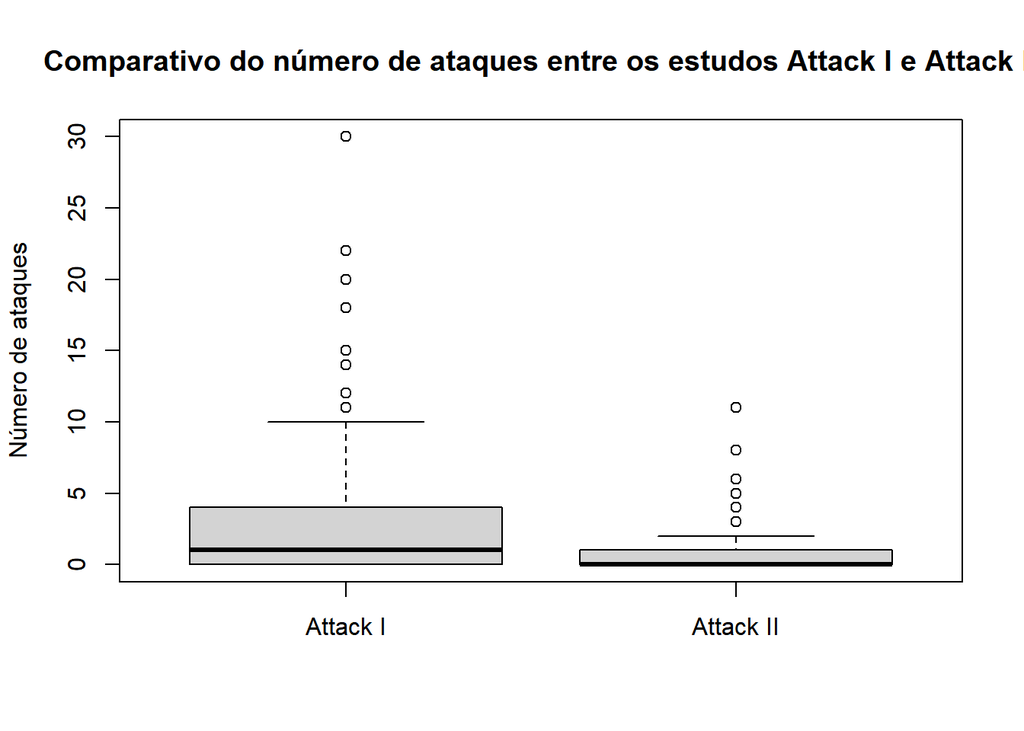

```
## t = 6.8832
```

```
## Graus de liberdade = 213.69
```

```
## p-valor = 6.40e-11
```

Os resultados dos testes são apresentados abaixo:

Barreira de acesso a exame?

| Barreira | N | Média | DP | t | GL | p | Inferior | Superior |
| --- | --- | --- | --- | --- | --- | --- | --- | --- |
| Não | 547 | 1.414991 | 2.887004 | -1.456678 | 22.61093 | 1.59e-01 | -3.732775 | 0.6497136 |
| Sim | 23 | 2.956522 | 5.040547 |  |  |  |  |  |

Barreira de acesso a transporte?

| Barreira | N | Média | DP | t | GL | p | Inferior | Superior |
| --- | --- | --- | --- | --- | --- | --- | --- | --- |
| Não | 467 | 1.220557 | 2.712348 | -3.50066 | 124.4292 | 6.45e-04 | -2.223188 | -0.6172521 |
| Sim | 103 | 2.640777 | 3.915415 |  |  |  |  |  |

Barreira de acesso a medicamento?

| Barreira | N | Média | DP | t | GL | p | Inferior | Superior |
| --- | --- | --- | --- | --- | --- | --- | --- | --- |
| Não | 334 | 0.8443114 | 1.601336 | -5.420106 | 285.5985 | 1.27e-07 | -2.083668 | -0.9734716 |
| Sim | 236 | 2.3728814 | 4.118038 |  |  |  |  |  |

Barreira de acesso a atenção básica?

| Barreira | N | Média | DP | t | GL | p | Inferior | Superior |
| --- | --- | --- | --- | --- | --- | --- | --- | --- |
| Não | 463 | 1.466523 | 3.103981 | -0.1967452 | 183.4531 | 8.44e-01 | -0.6268569 | 0.5131733 |
| Sim | 107 | 1.523365 | 2.589332 |  |  |  |  |  |

Teve alguma barreira de acesso?

| Barreira | N | Média | DP | t | GL | p | Inferior | Superior |
| --- | --- | --- | --- | --- | --- | --- | --- | --- |
| Não | 245 | 0.6938776 | 1.361112 | -6.156903 | 432.0328 | 1.70e-09 | -1.812378 | -0.9352514 |
| Sim | 325 | 2.0676923 | 3.704565 |  |  |  |  |  |

### Conclusão

Para a análise de ambos os estudos em conjunto foi verificado que houve maior significância estatística entre as barreiras de transporte e acesso aos medicamentos. Destaca-se que o fato de ter pelo menos uma barreira de acesso também teve significância com relação ao número de ataques. Este achado demonstra uma possível relação de barreiras ao número de ataques de um modo geral.